# Statistical Inference and estimation

## STAT 4101L

## Learning Objectives

After of completion of this lesson you will be able to understand and apply:

- Point estimation
- Confidence intervals
- Hypothesis testing
- ANOVA
- Test of independence

## Motivation

About 697,000 people die of heart disease in the United States every year–that's 1 in every 5 deaths. Coronary heart disease (CHD) is the most common type of heart disease, killing approximately 382,820 people annually. Every year about 805,000 Americans have a heart attack.

## Data and data exploration

```r
library(dplyr)
library(ggplot2)
health_data = read.csv("~/Desktop/STAT4101L_all_files/Stat4101L-Rfiles/DataSets/Lesson End Projects datasets/Lesson 6/heart.csv")
knitr::kable(head(health_data[,1:5]),  "simple")
```

```
HeartDisease      BMI  Smoking   AlcoholDrinking   Stroke
-------------  ------  --------  ----------------  -------
No              16.60  Yes       No                No
No              20.34  No        No                Yes
No              26.58  Yes       No                No
No              24.21  No        No                No
No              23.71  No        No                No
Yes             28.87  Yes       No                No
```

```r
unique(health_data$Race)
```

1. 'White'

2. 'Black'

3. 'Asian'

4. 'American Indian/Alaskan Native'

5. 'Other'

6. 'Hispanic'

## Application examples

1. Estimate the proportion of US adult population who have heart-disease. (about 6% of US adults reported having heart disease [https://www.cdc.gov/nchs/hus/topics/heart-disease-prevalence.htm]).
2. Examine the risk of heart disease among the ethnic group/gender (Black men have a 70% higher risk of heart failure compared with white men [https://my.clevelandclinic.org/health/articles/23051-ethnicity-and-heart-disease])
3. Estimate the average BMI of US adults
4. Check if there is any significant difference between the BMI of US adults by heart disease status yes/no.
5. Check if all the ethnic group have same effect on BMI of US adults.
6. Check if there is any association between heart disease and ethnicity.

# Probability distributions in R

1. Binomial distribution

```
x = number of successes
n = total number of trails
p = probablity of success
pmf : p(X = x), dbinom(x, size = n, prob = p)
CDF : p(X < x), pbinom(q, size = n, prob = p), q = quantile
inv_CDF : qbinom(CDF, size = n, prob = p) computes x
random variable: rbinom(r, size = n, prob = p), r = how many random number you want to draw
```

- Bernoulli distribution is specific case of Binomial distribution when size = 1
1. Uniform distribution

```
a = lower limit, b = upper limit
pdf : f(x; a, b) = 1/(b-a), dunif(x, a, b)
CDF : P(X < x), punif(q, a, b)
inv_CDF : qunif(CDF, a , b) computes x
random variable: runif(r, a, b), r = number of random varaibles that we want to draw
```

1. Normal distribution

```
mu = mean, sd = standard deviation
pdf : f(x; mu, sd), dnorm(x, mu, sd)
CDF : P(X < x), pnorm(q, mu, sd)
inv_CDF : qnorm(p, mu, sd) computes x
random variable: rnorm(r, mu, sd), r = number of random varaibles that we want to draw
```

```r
dnorm(10, mean = 74, sd = 5)
```

2.11123270049056e-37

- mean $\mu = 0$, and $sd = 1$ yields standard normal
1. t-distribution

```
df degree of freedom
dt(x, df, ncp, log = FALSE) computes density
pt(q, df, ncp, lower.tail = TRUE, log.p = FALSE) computes CDF
qt(p, df, ncp, lower.tail = TRUE, log.p = FALSE) computes quantile
rt(n, df, ncp) generates random number
```

1. chi-square distribution

```
dchisq(x, df, ncp = 0, log = FALSE)
pchisq(q, df, ncp = 0, lower.tail = TRUE, log.p = FALSE)
qchisq(p, df, ncp = 0, lower.tail = TRUE, log.p = FALSE)
rchisq(n, df, ncp = 0)
```

## Inference for proportions (Using normal approximation)

### 1. Inference for a single proportion (p) using normal approximation

**Assumptions**

The assumptions for inference for proportions using normal approximation typically include:

- Random Sample: The data should be collected from a random sample or a well-defined randomization process to ensure that it represents the population of interest without bias.
- Large Sample Size: The sample size should be sufficiently large. A common rule of thumb is that both np and n(1-p) should be greater than 5, where n is the sample size and p is the proportion of interest.
- Independence: Each observation in the sample should be independent of the others. The occurrence of one event should not affect the occurrence of another event in the sample.
- Approximately Normal Distribution: While the original distribution of the population may not necessarily be normal, the distribution of the sample proportion (p-hat) tends to be approximately normal for large sample sizes due to the Central Limit Theorem.

#### Estimation of population proportion

a. population proportion $$ p = \frac{\text{number of sucesses}}{\text{number of possible cases}}.$$

b. Point estimate: Sample proportion $$ \hat{p} = \frac{\text{number of sucesses in a sample of size n}}{\text{sample size n }}.$$

c. Sampling distribution of sample proportion $\hat{p}$ is approximately normal with mean = $p$ and $sd = \sqrt{\frac{p\ (1-p)}{n}}$, called standard error (SE).

d. Large sample $(1-\alpha)100\%$ confidence interval for p:

- Confidence interval estimation depends on the normal approximation, so we require independent trials and a large enough sample
- Confidence interval, $\hat{p} - E < p < \hat{p} + E$ is usually written as $\hat{p} \pm E$, where E is the margin of error.
- The margin of error $E = z_{\frac{\alpha}{2}} * SE$.
- $\alpha$ is called the level of significance, and $z_\frac{\alpha}{2}$ called the critical value

e. Most widely used confidence level is $95\%$, but you might see $90\%$ and $99\%$ sometimes.

f. Interpretation of $95\%$ confidence interval:

- We usually say we are 95% confident that the estimated confidence interval contains the true population proportion.
- The actual meaning is that when we construct the corresponding confidence intervals from each of all possible samples of same size, $95\%$ of the several constructed confidence interval estimates would actually contain the true value of the underlying population proportion.
- Does not mean the probability that the estimated confidence interval contains the true value is $95\%$.

### Example 1 (Point estimate and confidence interval estimate)

Estimate the proportion of US adult population who have heart-disease using the health_data.

a. Point estimate (sample proportion)

- Compute Manually

```r
p_hat = mean(health_data$HeartDisease == "Yes")
print(p_hat)
```

```
[1] 0.08559546
```

b. Confidence interval estimate

```r
n = nrow(health_data) # sample size
SE = sqrt(p_hat *(1-p_hat)/n)
alpha_half = (1 -.95)/2
Z_alpha_half = qnorm(1 -alpha_half)
E = Z_alpha_half * SE
L = p_hat - E; U = p_hat + E
```

```r
cat("95% confidence interval:", "\n")
cat("Lower limit = ", L,
    ",Upperr limit = ", U)
```

```
95% confidence interval:
Lower limit =  0.08462583 ,Upperr limit =  0.08656509
```

- Compute using prop.test function

**Syntax**

```
prop.test(x, n, p = NULL,
          alternative = c("two.sided", "less", "greater"),
          conf.level = 0.95, correct = TRUE)
```

?prop.test( ), get help for the full documentation.

```r
#`@ prop.test(x,n,correct=FALSE)
#`@ x = number of successes in a given sample
#`@ n = sample size
x =  sum(health_data$HeartDisease == "Yes")
prop.test(x,n, correct=TRUE)
```

```
	1-sample proportions test with continuity correction

data:  x out of n, null probability 0.5
X-squared = 219673, df = 1, p-value < 2.2e-16
alternative hypothesis: true p is not equal to 0.5
95 percent confidence interval:
 0.08462924 0.08657165
sample estimates:
         p
0.08559546
```

**Interpretation**

We are $95\%$ confident that the true proportion of US adult population who have heart-disease lies in between 0.0846 and 0.0866.

#### Hypothesis testing (testing claim about a population proportion)

a. claim: about 8.4% of US adults reported having heart disease

b. claim: less than 8.6% of US adults reported having heart disease

c. claim: more than 8.4% of US adults reported having heart disease

1. Type of test
   - if the original claim is about equality, it goes to null, and alternative is opposite of it.
   - if the original claim is about less or greater, it goes to alternative, and null is opposite of it ( many texts define null with equality only).

```
 a. Two tailed test:
```

```
  null            H0: p = p0
  alternative     H1: p ≠ p0
```

```
 b. Left-tailed
```

```
  null           H0: p ≥ p0
 alternative     H1: p < p0
```

```
c. Right-tailed
```

```
  null            H0: p ≤ p0
  alternative     H1: p > p0
```

1. Test statistic
   - It is a z-score calculated assuming null is true (or true value is at null)
   - It is an observed value from the data when null is true.

$$z = \frac{\hat{p} - p_0}{SE},\ SE = \sqrt{\frac{p_0(1-p_0)}{n}}.$$

1. Critical region or rejection region:
   - This region is defined based on a prespecified cutoff called the significance level ($\alpha$)
   - This region determines whether the null to be rejected or not.
   - If the test is two sided, $-z_\frac{\alpha}{2}$ and $z_\frac{\alpha}{2}$ are the critical values that separate the rejection region of normal density.
   - If the test is left-tailed, $-z_{\alpha}$ is a critical value that separates the rejection region of normal density.
   - If the test is right-tailed, $z_{\alpha}$ is a critical value that separates the rejection region of normal density.
1. p-value:

The P-value is the probability of observing the test statistic (i.e., summary of the data) that is as extreme or more extreme than currently observed test statistic when the null hypothesis is true. This can be expressed as Pr(data|H0)

- It is a probability value, that tells you how likely your data (or test statistic) could have occurred when null hypothesis is true.
- This tells you whether the observed value (or test statistic) is an extreme value (unacceptable by the data ) or not when null is true
- Two tailed test: p-value = 2*p(z > |T|)
- Left tailed test: p-value = p(z < T)

## Right tailed test: p-value = p(z > T)

1. Test conclusion
   - If $p-value > \alpha$, we fail to reject the null (we cannot accept the alternative but we don't say accept the null )
   - If $p-value < \alpha$, we reject the null (we can say accept the alternative )
   - If original claim is null then we either fail to reject the claim or reject the claim
   - If original claim is alternative then eitherwe do not support the claim or we suppoort the claim.

**Computation of p-value In R**

```
Two tailed test: p-value = 2*(1- pnorm(|z|))
Left tailed test:  p-value = pnorm(z)
Right tailed test:  p-value = 1- pnorm(z)
```

### Recall:

1. estimation for population proportion (p)
   - Point estimate, Sample proportion ($\hat{p}$)
   - Confidence interval, $ \hat{p}\pm E$
1. Hypothesis testing of proportion
   - Two tailed test
   - Left tailed test
   - Right tailed test

### Example 2 (Hypothesis tesing for one proportion)

a. claim: about 8.4% of US adults reported having heart disease, use $\alpha = 0.05$

```
  null            H0: p = 0.084
  alternative     H1: p ≠ 0.084
```

```r
prop.test(x, n, p = 0.084,
          alternative = "two.sided")
```

```
	1-sample proportions test with continuity correction

data:  x out of n, null probability 0.084
X-squared = 10.559, df = 1, p-value = 0.001156
alternative hypothesis: true p is not equal to 0.084
95 percent confidence interval:
 0.08462924 0.08657165
sample estimates:
         p
0.08559546
```

**Test conclusion**

- p-value = 0.001156 is less than significance level 0.05
- We reject the null
- Hence, we have sufficient evidence to reject the claim that about 8.4% of US adults reported having heart disease.

b. claim: less than 8.6% of US adults have heart disease, use $\alpha = 0.05$

```
Null, H0: p = 0.086, Alt H1: p < 0.086
```

```r
prop.test(x, n, p = 0.086,
          alternative = "less")
```

```
	1-sample proportions test with continuity correction

data:  x out of n, null probability 0.086
X-squared = 0.66067, df = 1, p-value = 0.2082
alternative hypothesis: true p is less than 0.086
95 percent confidence interval:
 0.00000000 0.08641428
sample estimates:
         p
0.08559546
```

- p-value = 0.2082 is greater than significance level 0.05
- We fail to reject the null (we cannot support the alternative)
- Hence, we do not have sufficient evidence to support the claim that less than 8.6% of US adults have heart disease.

```r
prop.test(x, n, p = 0.084,
          alternative = "greater")
```

```
	1-sample proportions test with continuity correction

data:  x out of n, null probability 0.084
X-squared = 10.559, df = 1, p-value = 0.0005782
alternative hypothesis: true p is greater than 0.084
95 percent confidence interval:
 0.08478366 1.00000000
sample estimates:
         p
0.08559546
```

### Comparing two proportions (proportion of two independent groups)

**Example:** Examine the risk of heart disease among the ethnic groups: Black and White.

a. Confidence interval for the difference of two proportions

- Confidence interval:

  $$(\hat{p_1} - \hat{p_2}) - E < p_1 - p_2 < \hat{p_1} - \hat{p_2}) + E$$
- Margin of error:

$$E = z_{\frac{\alpha}{2}} * SE,\ \ SE = \sqrt{\frac{p_1(1-p_1)}{n_1} + \frac{p_2(1-p_2)}{n_2}}.$$

b. Hypothesis test for difference of two proportions

- Test statistic

  $$ T = \frac{\hat{p_1} - \hat{p_2}}{SE}.$$

```r
p_hat = health_data %>%
  filter(Race %in% c("Black", "White"))  %>%
  group_by(Race) %>%
  summarise(sample_size = n(), successes = sum(HeartDisease == "Yes"), p_hat = mean(HeartDisease == "Yes"))

knitr::kable(p_hat)
```

```
|Race  | sample_size| successes|     p_hat|
|:-----|-----------:|---------:|---------:|
|Black |       22939|      1729| 0.0753738|
|White |      245212|     22507| 0.0917859|
```

```
  Two sided test

  H0: pB -pW = 0
  H1: pB -pW ≠ 0
```

```r
prop_diff <- prop.test(x = c(1729, 22507),
                       n = c(22939, 245212),
                       alternative = "two.sided")
# x vector of successes
# n vector of sample sizes
# Printing the results
prop_diff
```

```
	2-sample test for equality of proportions with continuity correction

data:  c(1729, 22507) out of c(22939, 245212)
X-squared = 68.527, df = 1, p-value < 2.2e-16
alternative hypothesis: two.sided
95 percent confidence interval:
 -0.02003825 -0.01278588
sample estimates:
    prop 1     prop 2
0.07537382 0.09178588
```

**Test conclusion**

- p-value < 2.2e-16, the null is rejected
- There is sufficient evidence to reject the claim that proportion of heart disease of Black population and that of white population are aqual.

```
Left-tailed test

H0: pB -pW = 0
H1: pB -pW < 0
```

```r
prop_diff <- prop.test(x = c(1729, 22507), n = c(22939, 245212), alternative = "less")
# Printing the results
prop_diff
```

```
	2-sample test for equality of proportions with continuity correction

data:  c(1729, 22507) out of c(22939, 245212)
X-squared = 68.527, df = 1, p-value < 2.2e-16
alternative hypothesis: less
95 percent confidence interval:
 -1.00000000 -0.01336504
sample estimates:
    prop 1     prop 2
0.07537382 0.09178588
```

**Test conclusion**

- p-value < 2.2e-16, the null is rejected
- There is sufficient evidence to support the claim that proportion of heart disease of Black population is less than that of the white population.

[output not shown]

```r
prop_diff <- prop.test(x = c(1729, 22507), n = c(22939, 245212), alternative = "greater")

# Printing the results
prop_diff
```

```
	2-sample test for equality of proportions with continuity correction

data:  c(1729, 22507) out of c(22939, 245212)
X-squared = 68.527, df = 1, p-value = 1
alternative hypothesis: greater
95 percent confidence interval:
 -0.01945909  1.00000000
sample estimates:
    prop 1     prop 2
0.07537382 0.09178588
```

## Inference for Means (Using normal approximation)

### 1. Estimation of population mean from sample data

- The best point estimate for population mean $\mu$ is sample mean $\bar {X}$.
- The confidence interval estimate for mean $\mu$ is $\bar{X} - E < \mu < \bar{X} + E,$ where
  - For known variance, $E = z_{\frac{\alpha}{2}} * SE$, and $SE = \frac{\sigma}{\sqrt{n}}$ (from normal distribution).
  - For unknown variance, $E = t_{\frac{\alpha}{2},\ df=n-1} * SE$, and $SE = \frac{s}{\sqrt{n}}$ (from t-distribution). (**Note: This is the usual case.**)
- The confidence interval can be written as $\bar{X} \pm E$.
- Example:

a. Estimate the average BMI of US adults

```r
avg_BMI = mean(health_data$BMI)
print(avg_BMI)
```

```
[1] 28.3254
```

b. Construct a $95\%$ confidence interval for the mean BMI of US adults.

- Manual computation

```r
X_bar = mean(health_data$BMI)
s = sd(health_data$BMI)
n = nrow(health_data)
alpha = 0.05
alpha_half = alpha/2
t = 1 - qt(alpha_half, df = n-1)
SE = s/sqrt(n)
E = t * SE
L = X_bar - E; U = X_bar + E
cat('95% confidence interval is', '\n')
cat('Lower limit: ', L, ',', 'Upper limit: ', U)
```

```
95% confidence interval is
Lower limit:  28.29213 , Upper limit:  28.35867
```

- Using t-test function

```r
x = health_data$BMI
t.test(x, conf.level = 0.95)
```

```
	One Sample t-test

data:  x
t = 2520.1, df = 319794, p-value < 2.2e-16
alternative hypothesis: true mean is not equal to 0
95 percent confidence interval:
 28.30337 28.34743
sample estimates:
mean of x
  28.3254
```

### 2. Hypothesis testing (testing claim about a population mean)

```
t.test(x, y = NULL,
       alternative = c("two.sided", "less", "greater"),
       mu = 0, paired = FALSE, var.equal = FALSE,
       conf.level = 0.95, ...)
```

According to the National Health and Nutrition (NHN) Survey, the average adult population of the United States has a BMI of around 28.29.

a. Test whether the BMI of health data supports the above claim, use significance level equals 0.1.

```
  null            H0: mu = 28.29
  alternative     H1: mu ≠ 28.29
```

```r
x = health_data$BMI
t.test(x, alternative = "two.sided", mu = 28.29)
```

```
	One Sample t-test

data:  x
t = 3.1494, df = 319794, p-value = 0.001636
alternative hypothesis: true mean is not equal to 28.29
95 percent confidence interval:
 28.30337 28.34743
sample estimates:
mean of x
  28.3254
```

**Test conclusion**

```
  - p-value = 0.001636 and given significance level is 0.1
  - Since p-value is less than significance level we reject the null
  - Hence, we have sufficient evidence to reject the claim that average BMI of US adults is 28.29.
```

b. Test the claim that BMI of Black US adults is greater than 30.1, use significance level equals 0.05.

```
  null            H0: mu = 30.1
  alternative     H1: mu > 30.1
```

```r
x = health_data %>% filter( Race == "Black") %>% select(BMI)
x = unlist(x)
t.test(x, alternative = "greater", mu = 30.1)
```

```
	One Sample t-test

data:  x
t = 1.4728, df = 22938, p-value = 0.07041
alternative hypothesis: true mean is greater than 30.1
95 percent confidence interval:
 30.09182      Inf
sample estimates:
mean of x
 30.16999
```

**Test conclusion**

- p-value = 0.07041 is greater than the sig level = 0.05.
- We fail to reject the null.
- We do not have sufficient evidence to support the claim that BMI of Black US adults is greater than 30.1

c. Test the claim that BMI of Asian US adults is less than 25.3. use significance level equals 0.05.

```
  null            H0: mu = 25.3
  alternative     H1: mu < 25.3
```

```r
x = health_data %>% filter( Race == "Asian") %>% select(BMI)
x = unlist(x)
t.test(x, alternative = "less", mu = 25.3)
```

```
	One Sample t-test

data:  x
t = -1.5048, df = 8067, p-value = 0.0662
alternative hypothesis: true mean is less than 25.3
95 percent confidence interval:
     -Inf 25.30761
sample estimates:
mean of x
  25.2183
```

**Test conclusion**

- p-value = 0.0662 is greater than the sig level = 0.05.
- We fail to reject the null.
- We do not have sufficient evidence to support the claim that BMI of Asian US adults is less than 25.3.

### Comparing the means of two independent groups (two independent samples t-test)

- Independent samples:
  - Cases of each group are unrelated (or are not naturally paired/matched) to one another.
  - Not necessarily of same sizes
- Dependent samples:
  - Cases of each group are somehow related (or are naturally paired/matched) to one another.
  - Always of same sizes
- The two-sample t-test (aka **independent samples t-test**) is a method used to test whether the unknown population means of two independent groups are equal or not.
- **Requirements(or assumptions):**
  - data values are independent, are randomly sampled from two normal populations
  - two independent groups have equal variances (Homogenity of varaince)

### 1. Confidence interval for difference between the means of two groups.

```
  a. Provide the point estimate of the difference between the mean BMI of male and female population.

  b. Construct $95\%$ confidence interval estimate of the difference between the mean BMI of male and female population.
```

```r
gender_mean_BMI = health_data %>%
                    group_by( Sex) %>%
                    summarise(sample_mean = mean(BMI))

knitr::kable(gender_mean_BMI)
```

```
|Sex    | sample_mean|
|:------|-----------:|
|Female |    28.16244|
|Male   |    28.50532|
```

```r
# condidence interval for difference of means (independent sample t-test) for means
male_BMI = health_data %>%
       filter(Sex == "Male") %>%
        select(BMI)

female_BMI = health_data %>%
         filter(Sex == "Female") %>%
        select(BMI)

t.test(x = male_BMI, y = female_BMI, conf.level = 0.95)
```

```
	Welch Two Sample t-test

data:  male_BMI and female_BMI
t = 15.368, df = 318168, p-value < 2.2e-16
alternative hypothesis: true difference in means is not equal to 0
95 percent confidence interval:
 0.2991518 0.3866106
sample estimates:
mean of x mean of y
 28.50532  28.16244
```

### 2. Hypothesis testing for the mean differences of two groups.

```
a. Test the claim that there is no significant difference between the BMI of Asian and Hispanic population.
```

```
  null            H0: mu_A = mu_H
  alternative     H1: mu_A ≠ mu_H
```

```r
A_BMI = health_data %>% filter( Race == "Asian") %>% select(BMI)
H_BMI = health_data %>% filter( Race == "Hispanic") %>% select(BMI)
t.test(x = A_BMI, y = H_BMI, alternative =  "two.sided")
```

```
	Welch Two Sample t-test

data:  A_BMI and H_BMI
t = -53.612, df = 17438, p-value < 2.2e-16
alternative hypothesis: true difference in means is not equal to 0
95 percent confidence interval:
 -3.731395 -3.468170
sample estimates:
mean of x mean of y
 25.21830  28.81809
```

**Conclusion**: We reject the claim that there is no significant difference between the BMI of Asian and Hispanic population.

```
b. Test the claim that White population has lower BMI than the that of Black population in average.
```

```
  null            H0: mu_W = mu_B
  alternative     H1: mu_W < mu_B
```

```r
B_BMI = health_data %>% filter( Race == "Black") %>% select(BMI)
W_BMI = health_data %>% filter( Race == "White") %>% select(BMI)
t.test(x = W_BMI, y = B_BMI, alternative =  "less")
```

```
	Welch Two Sample t-test

data:  W_BMI and B_BMI
t = -41.036, df = 26210, p-value < 2.2e-16
alternative hypothesis: true difference in means is less than 0
95 percent confidence interval:
      -Inf -1.935738
sample estimates:
mean of x mean of y
 28.15342  30.16999
```

**Test Conclusion**

- p-value < 2.2e-16 is less than 0.05.
- We support the claim that White population has lower BMI than that of Black population in average.

```
c. Test the claim that Asian population has lower BMI than the that of white population in average.
```

[output not shown]

### 3. Comparing results from two dependent groups (pairwise t-test)

- The pairwise t-test is a method used to compare the means of two measurements taken from the same individual, object, or naturally paired units.

```
t.test(x, y = NULL,
       alternative = c("two.sided", "less", "greater"),
       mu = 0, paired = TRUE)
```

**Example 1:**

We want to compare the height of the married couples. You selected a sample of 10 couples.

```
H0: mu_d = 0
H1: mu_d is not equal 0
```

```r
Woman_height = c(5.3, 4.9, 5.5, 5.2, 5.7, 5.4, 5.9, 5.6, 5.0, 5.5)
Husband_height = c(5.6, 5.9, 5.4, 5.7, 5.6, 5.9, 6.39, 5.9, 5.3, 5.2)
d = Husband_height - Woman_height
cat("difference of the height of married couples")
round(d,2)
```

```
difference of the height of married couples
```

1. 0.3

2. 1

3. -0.1

4. 0.5

5. -0.1

6. 0.5

7. 0.49

8. 0.3

9. 0.3

10. -0.3

```r
t.test(x = Woman_height, y = Husband_height,
       alternative = "two.sided",
      paired = TRUE)
```

```
	Paired t-test

data:  Woman_height and Husband_height
t = -2.4187, df = 9, p-value = 0.03869
alternative hypothesis: true mean difference is not equal to 0
95 percent confidence interval:
 -0.55929281 -0.01870719
sample estimates:
mean difference
         -0.289
```

We want test whether the test score is significantly improved in test two than test one. A comparison is made based on test scores of 35 randomly selected students from a Statistics class.

## Analysis of Variance (ANOVA)

When a dependent (quantitative) variable is further categorized into multiple treatments (or factors), and we want to compare the effect of those treatment groups on the given dependent variable we use ANOVA method.

### Example 1 (One way ANOVA)

We want to investigate how the BMI differs between the various races of the US population.

### Example 2 (Two way ANOVA)

We want to examine the effect of irrigation and sunlight exposure on crop yield

- t-test examines whether means of two groups are different or not,
- while ANOVA can be used for more than two groups.

## One way ANOVA

When the dependent variable is categorized (or describe) according to one way ( by one treatment/factor) into more than two independent groups, and we want to examines the effects (or means) of those independent groups on the dependent variable, we use one way ANOVA.

### Example 1 (One way ANOVA)

We have a sample data that describes BMI of randomly selected 500 US adults which is divided into multiple groups by race, and first 25 samples is given in 5 rows below:

**BMI by race**

```r
# simulated sample data
df = data.frame(White = runif(5, 20, 28),
                Black = runif(5, 21, 30),
                Asian = runif(5, 18, 25),
                Hispanic = runif(5, 21, 29),
                Others = runif(5, 23, 30)
)
df = round(df, 1)
knitr::kable(df)
```

```
| White| Black| Asian| Hispanic| Others|
|-----:|-----:|-----:|--------:|------:|
|  25.8|  24.1|  22.2|     24.1|   29.6|
|  26.5|  26.3|  20.2|     24.1|   23.2|
|  21.5|  29.2|  18.4|     27.8|   26.5|
|  21.1|  24.2|  20.9|     28.1|   23.0|
|  21.7|  28.0|  24.7|     22.8|   25.3|
```

a. Here the response variable is BMI, which is divided by one factor/treatment race (with five categories/groups).

b. If we want to compare mean BMIs of two races, we use two-independent sample t-test,

c. If we want to compare means of more than two races, we use one way ANOVA.

- Why don't we use pair-wise t-test?

  a. Computational complexity: comparing 5 groups, we require $C(5,2) = 10$ pair-wise t-test.

  b. Problem with type I error: when number of pair increases, type I error increases exponentially, so we have a problem of rejecting the null in most of the cases.

[figure not shown]

### One way ANOVA testing framework

For k-many groups,

\begin{eqnarray*} \text{Null } && H_0: \mu_1 = \mu_2 = \ldots, \mu_k, \text { (all the means are same) }\\ \text{Alternative } && H_1: \text{ at least two means are unequal/ at least one mean is different from others} \end{eqnarray*}

- Why do we define alternative in this way instead of saying all the means are different?
  - Alternative is a statement that contradicts null, so we consider a weak statement that is enough to contradict the null. (note: if we say all the means are different, it is vary strong, we do not use it as an alternative).
  - It means that some can be equal but not all.
  - The alternative hypothesis in one-way ANOVA is designed to capture the general idea that there are differences among the group means, without restricting it to a specific pattern of differences.
- Test conclusion based on p-value and $\alpha$
  - If p-value is greater than $\alpha$, we fail to reject the null, (so it is reasonable to say all means are equal)
  - If p-value is less than $\alpha$, we reject the null, so we have sufficient evidence to say that at least two means are different.
- Does ANOVA suggest us which means are different and how they are different?
  - If the null of one way ANOVA rejected, we can say at least two means are different, but ANOVA does not suggest which pairs are different and how they differ.
  - To find such pairs we need to use pair-wise comparision, for this course we use **modified pairwise comparision t-test**.
- Does ANOVA requires equal sample size for each group?
  - No, ANOVA does not require equal sample sizes.

### Requirements:

```
- The population have distribution that are approximately normal
- The population for each group has same varaince (or same standard deviation)
- The samples are SRS and independent among the groups
- Data is categorized in only one way (Treatment/factor)
```

### Test Statistics

- F-statistic $F = \frac{MS(Treatment)}{MS(Error)} \approx \frac{\text{variance between sample means}}{\text{variance within samples}}$
  - F-statistic is the ratio of two varainces: variance between the groups and variance within groups.
  - If all the means are approximately equal, then numerator becomes small and so is F-statistic, and vice versa,
  - If means are different, the numerator becomes large and so is F-statistic, and vice versa
  - Hence, smaller F-score supports Null, while larger value supports alternative.
- Why do we call this method Analysis of variance even though we are comparing the means?
  - Even though our goal of study is to comapre the means between the groups, our test conclusion is based on comparing the varaince between the gorups and within the groups.
  - Hence, we refer this method as Analysis of varaince.

### Test conclusion of ONE WAY ANOVA

1. $p-value < \alpha$
   - Initial conclusion: if p-value is less than $\alpha$ we reject the null (i.e. accept alternative)
   - Formal conclusion: We have sufficient evidence to say that at least one mean is different from others.
   - In this case we can say at least two groups have different mean (different effect).
2. $p-value \geq \alpha$
   - Initial conclusion: if p-value is greater than $\alpha$ we fail to reject the null
   - Formal conclusion: There is insufficient evidence to reject the claim that all the means are same.
   - In this case we might think of all the groups have same mean (same effect).

**One-Way Anova in R**

- Test the effect of Race on BMI's, i.e. examine whether the BMI differs by race among Black, White and Hispanic.

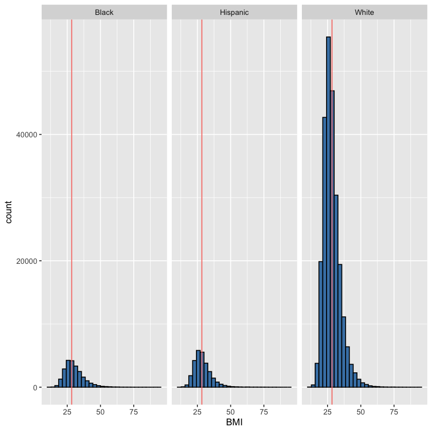

```r
library(ggplot2)
df <- health_data %>% filter(Race %in% c('Black', 'White', 'Hispanic'))
stat_summary <- df %>%
  group_by(Race) %>%
  summarise(mean_BMI = mean(BMI))

ggp <- ggplot(df, aes(x=BMI))+
  geom_histogram(color="black", fill="steelblue")+
  geom_vline(aes(xintercept=mean(BMI), col = 'red'), show.legend = FALSE) +
  facet_wrap(Race ~ .)
ggp
```

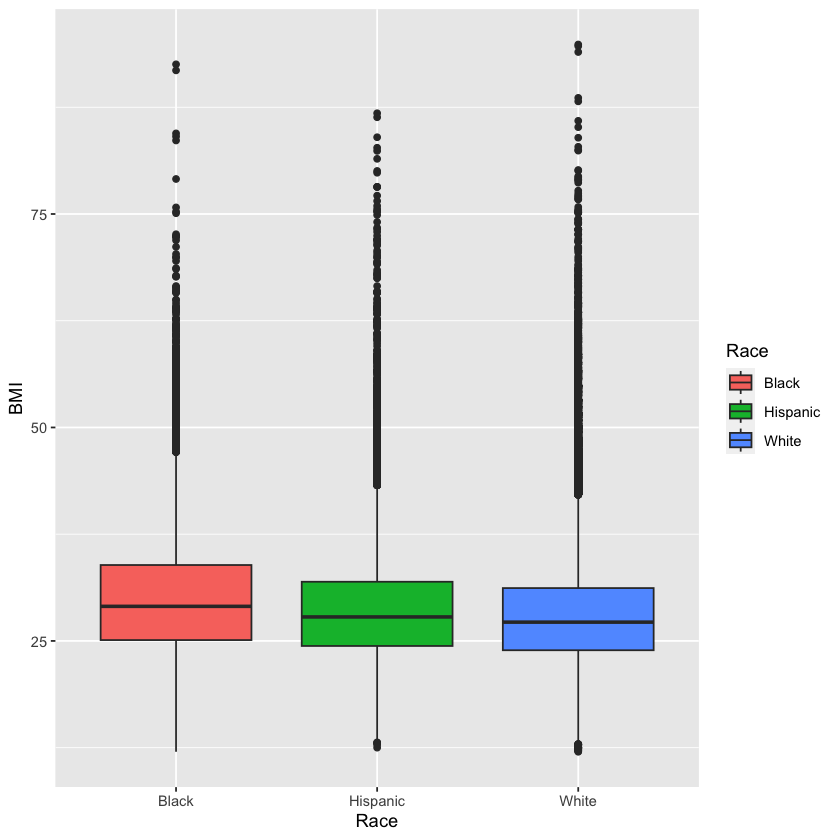

```r
# Change box plot colors by groups
p<- ggplot(df, aes(y=BMI, x=Race,  fill= Race)) +
   geom_boxplot()
p
```

#### Normality using quantile-quantile plot

If the data is normally distributed, the points in a Q-Q plot will lie on a straight diagonal line.

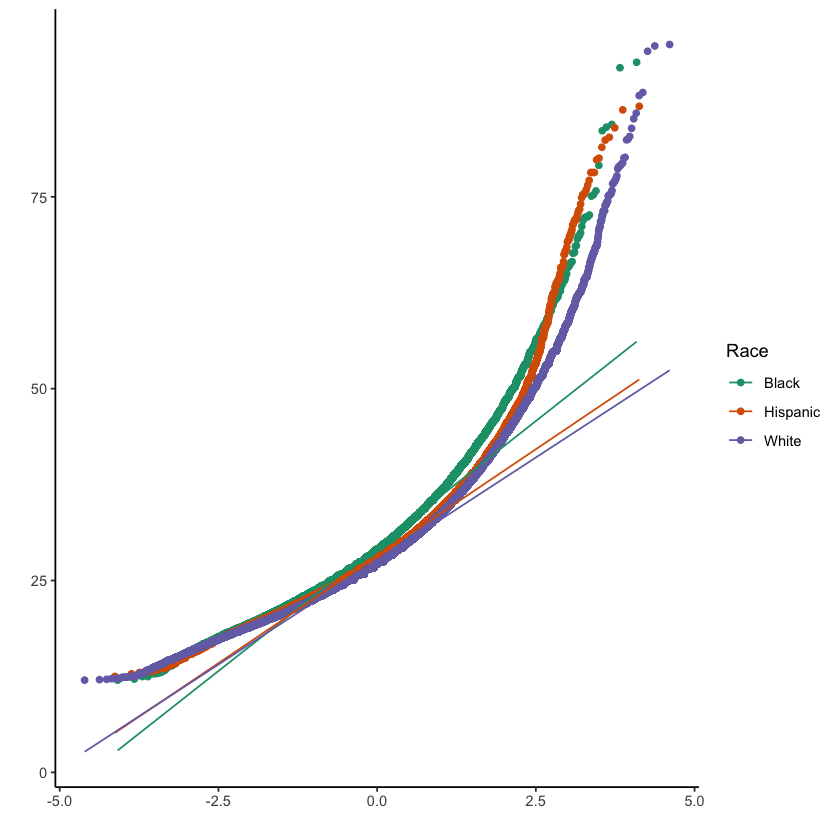

```r
# Change qq plot colors by groups
ggp<-qplot(sample = BMI, data = df, color=Race)
ggp +
  stat_qq_line() +
  scale_color_brewer(palette="Dark2") +
  theme_classic()
```

```r
Anova1 <- aov(BMI ~ Race, data = df)
summary(Anova1)
```

```
                Df   Sum Sq Mean Sq F value Pr(>F)
Race             2    91334   45667    1148 <2e-16 ***
Residuals   295594 11760469      40
---
Signif. codes:  0 ‘***’ 0.001 ‘**’ 0.01 ‘*’ 0.05 ‘.’ 0.1 ‘ ’ 1
```

**Interpretation of the result of one-way ANOVA tests**

As the p-value is less than the significance level 0.05, we can conclude that there are significant differences between the groups means of BMI.

#### Multiple pairwise-comparison between the means of groups

In one-way ANOVA test, rejecting null indicates that some of the group means are different, but we don’t know which pairs of groups are different.

It’s possible to perform multiple pairwise-comparison, to determine if the mean difference between specific pairs of group are statistically significant.

**Tukey multiple pairwise-comparisons**

We can compute Tukey HSD (Tukey Honest Significant Differences, R function: TukeyHSD()) for performing multiple pairwise-comparison between the means of groups.

- The function TukeyHSD( ) takes the fitted ANOVA as an argument.

```r
TukeyHSD(Anova1)
```

```
  Tukey multiple comparisons of means
    95% family-wise confidence level

Fit: aov(formula = BMI ~ Race, data = df)

$Race
                     diff        lwr        upr p adj
Hispanic-Black -1.3519078 -1.4841562 -1.2196593     0
White-Black    -2.0165711 -2.1186411 -1.9145011     0
White-Hispanic -0.6646634 -0.7587581 -0.5705686     0
```

The above result shows that all the means are different.

## Two-Way ANOVA

Recall: ANOVA stands for analysis of variance and it tests the effects of various treatment group on a quantitative dependent variable.

- When a dependent variable is further categorized by two different treatments (or factors) and we want to examine the effect of two treatments (or factors) on the dependent variable, we use two way ANOVA.
- A two-way ANOVA tests the effect of two independent variables on a dependent variable.
- It also examines whether the dependent variable is affected by the interaction of two factors (or treatment ) or not.

### Example 1 (Two way ANOVA)

```
- Here, response BMI
- factor (or treatment ), race
- factor (or treatment ), gender
```

**BMI by Race and Gender**

```r
# construct an example of sample data
set.seed(0)
df1 = cbind(White = runif(45, 20, 28),
                Black = runif(45, 21, 30),
                Asian = runif(45, 18, 27),
                Hispanic = runif(45, 21, 29)
)
rownames(df1) = rep("Male", 45)

df2 = cbind(
                White = runif(45, 20, 28)-1,
                Black = runif(45, 21, 30)-1,
                Asian = runif(45, 18, 25)-1,
                Hispanic = runif(45, 21, 29)-1
)

rownames(df2) = rep("Female", 45)

df = rbind(df1, df2)
df = round(df, 1)
knitr::kable(as.table(head(df,5)))
```

```
|     | White| Black| Asian| Hispanic|
|:----|-----:|-----:|-----:|--------:|
|Male |  27.2|  25.8|  19.3|     28.4|
|Male |  22.1|  28.1|  20.2|     25.8|
|Male |  23.0|  21.2|  18.5|     25.5|
|Male |  24.6|  25.3|  23.8|     25.2|
|Male |  27.3|  27.6|  25.9|     28.9|
```

**Mean BMI by race**

```r
tt = colMeans(df)
knitr::kable(tt)
```

```
|         |        x|
|:--------|--------:|
|White    | 23.75000|
|Black    | 24.95222|
|Asian    | 20.96222|
|Hispanic | 24.77667|
```

**Mean BMI by gender**

```r
tt = c(mean(df1), mean(df2))
names(tt) = c("Male", "Female")
knitr::kable(tt)
```

```
|       |        x|
|:------|--------:|
|Male   | 24.36048|
|Female | 22.86005|
```

**Check Interaction**

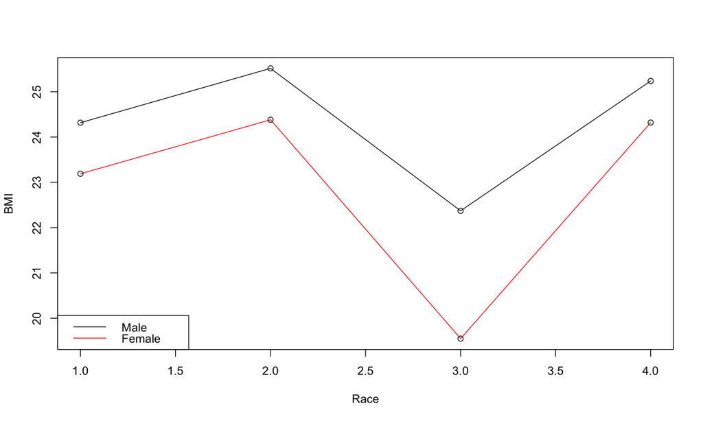

```r
t1 = colMeans(df1)
t2 = colMeans(df2)
options(repr.plot.width = 10, repr.plot.height = 6)
plot(1:4, t1, 'l', ylim = range(t1, t2), xlab = "Race", ylab = "BMI")
points(1:4, t1)
lines(1:4, t2, 'l', col = 'red')
points(1:4, t2)
legend(x = "bottomleft",
       #inset = c(-.2, 0), # You will need to fine-tune the first
                            # value depending on the windows size
       legend = c("Male", "Female"),  # Legend texts
       #lty = c(1, 2),
       col = c('black', 'red'), # Line colors
       lwd = 1,
       xpd = TRUE) # You need to specify this graphical parameter to
                   # put the legend outside the plot
```

### Example 2 (Two way ANOVA)

We want to examine the effect of irrigation and sunlight exposure on crop yield

```r
set.seed(123)
df1 = cbind(
                Low = runif(45, 2, 4),
                Midium = runif(45, 2.5, 5),
                High = runif(45, 2.1, 4.5)
)
rownames(df1) = rep("Low", 45)

df2 = cbind(
                Low = runif(45, 2, 3),
                Midium = runif(45, 3, 5),
                High = runif(45, 3.5, 5.5)
)
rownames(df2) = rep("High", 45)

df = rbind(df1, df2)
df = round(df, 1)
knitr::kable(head(df[sample(90, 20),],10))
```

```
|     | Low| Midium| High|
|:----|---:|------:|----:|
|Low  | 2.6|    2.5|  3.5|
|Low  | 2.9|    3.9|  3.3|
|High | 2.0|    4.1|  4.6|
|High | 2.2|    4.8|  3.6|
|High | 2.7|    3.5|  3.8|
|Low  | 3.9|    3.0|  3.5|
|Low  | 3.3|    3.6|  3.8|
|High | 2.4|    3.5|  4.4|
|Low  | 3.4|    4.4|  2.4|
|Low  | 3.1|    3.6|  4.0|
```

```r
# Let convert  row-factor and column-factor in to two columns
d1 = c(runif(45, 2, 4), runif(45, 2.5, 5),runif(45, 2.1, 4.5))
d2 = c(runif(45, 2, 3), runif(45, 3, 5),runif(45, 3.5, 5.5))
irreg_lev = rep(c('low', 'medium', 'high'), each = 45)
sun_exp = rep(c('low', 'high'), each = 135)
df_yield = data.frame(sun_exp, irreg_lev, production = c(d1, d2))
subset_df = head(df_yield[sample(nrow(df_yield), 10), ], 10)
rownames(subset_df) = NULL
knitr::kable(subset_df)
```

```
|sun_exp |irreg_lev | production|
|:-------|:---------|----------:|
|high    |low       |   2.687743|
|high    |high      |   5.006220|
|low     |low       |   2.069750|
|high    |low       |   2.093917|
|low     |medium    |   2.841350|
|high    |medium    |   3.173880|
|low     |low       |   2.829471|
|high    |low       |   2.000465|
|low     |medium    |   3.547290|
|high    |medium    |   3.929428|
```

```
- Here, response is rice production (in metric tons)
- factor1 (or treatment1 )is Sunlight exposure
- factor2 (or treatment2 ) is Irrigation
- Interaction term is Sunlight exosure * Irrigation
```

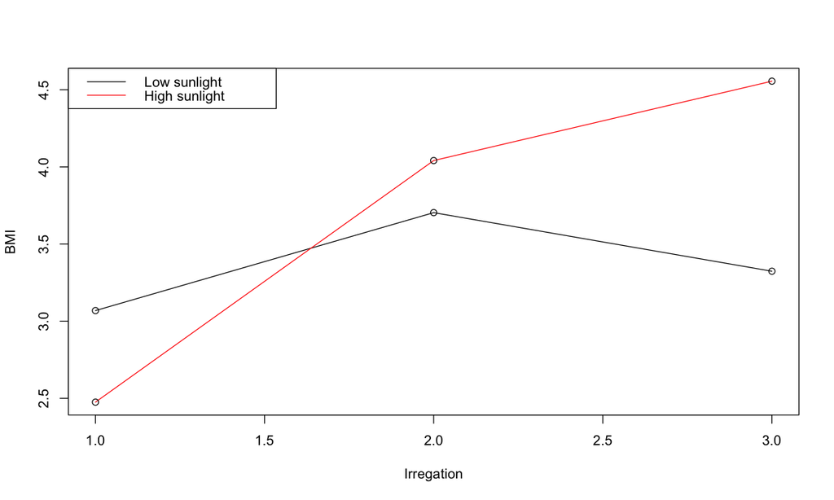

```r
set.seed(123)
t1 = colMeans(df1)
t2 = colMeans(df2)
plot(1:3, t1, 'l', ylim = range(t1, t2), xlab = "Irregation", ylab = "BMI")
points(1:3, t1)
lines(1:3, t2, 'l', col = 'red')
points(1:3, t2)
legend(x = "topleft",
       #inset = c(-.2, 0), # You will need to fine-tune the first
                            # value depending on the windows size
       legend = c("Low sunlight", "High sunlight"),  # Legend texts
       #lty = c(1, 2),
       col = c('black', 'red'), # Line colors
       lwd = 1,
       xpd = TRUE) # You need to specify this graphical parameter to
                   # put the legend outside the plot
```

### Interaction effect

- Interaction effects represent the combined effects of factors on the dependent measure.
- When an interaction effect is present, the impact of one factor depends on the level of the other factor.
- ANOVA has the ability to test interaction effects.

Therefore, in two way ANOVA we examine the following:

a. Interaction effect

- If we found any significance of interaction effect, then we considering an interaction term in regression model is significant ($y = \beta_0 + \beta_1 X_{treat_1} + \beta_2 X_{treat_2} + \gamma X_{treat_1} * X_{treat_2}$.)
- If there is no evidence of interaction effect, then we can only consider an additive model ($y = \beta_0 + \beta_1 X_{treat_1} + \beta_2 X_{treat_2}$.)

b. Factor1 (Row) effect

- We test whether the variability of groups in Factor1 is significant or just occurred by chance.
- having Factor1 effect means at least one group has different effect (or mean ) than others

c. Factor2 (Column) effect

- We test whether the variability of groups in Factor2 is significant or just occurred by chance.
- having Factor2 effect means at least one column group has different effect (or mean ) than others
- **Note that effect of factor1 and factor 2, i.e. $\beta_1 X_{treat_1} + \beta_2 X_{treat_2}$ is jointly called main effect**

### Two Way ANOVA Test

#### Requirements:

- Population distribution of each group is approximately normal
- Population have the same variance (homogeneity of variance)
- The samples ar SRS
- The samples are from populations that are categorized in two ways

### Hypothesis tesing

Step 1: Test for Main effect (i.e row effect and column effect)

a. Test for Row effect

\begin{eqnarray*} \text{Null } && H_0: \text { there is no row effect }\\ \text{Alternative } && H_1: \text{There is a row effect} \end{eqnarray*}

- Finds the F-statistic and p-value of the row effect
- If p-value < alpha, we have sufficient evidence to say that there is a row effect
- Otherwise, we have insufficient evidence to reject the claim that all the groups have same effect (there is no row effect).

b. Test for column effect

\begin{eqnarray*} \text{Null } && H_0: \text { there is no column effect }\\ \text{Alternative } && H_1: \text{There is a column effect} \end{eqnarray*}

- Finds the F-statistic and p-value of the column effect
- If p-value < alpha, we have sufficient evidence to say that there is a column effect
- Otherwise, we have insufficient evidence to reject the cliam that all the groups have same effect ( there is no column effect).

Step 2: Test for interaction effect

\begin{eqnarray*} \text{Null } && H_0: \text { there is no interaction effect }\\ \text{Alternative } && H_1: \text{There is an interaction effect} \end{eqnarray*}

- Finds the F-statistic and p-value of the interaction effect
- If p-value < alpha, we have sufficient evidence to say that there is an interaction effect, then interaction model is significant .
- If p-value > < alpha, we have insufficient evidence to say that there is an interaction effect, then additive model is well enough to model the response.

### Two-way ANOVA in R

```r
anova2 = aov(production ~ sun_exp + irreg_lev + sun_exp * irreg_lev, data = df_yield)
summary(anova2)
```

```
                   Df Sum Sq Mean Sq F value   Pr(>F)
sun_exp             1   8.12    8.12   23.02 2.68e-06 ***
irreg_lev           2  82.54   41.27  117.04  < 2e-16 ***
sun_exp:irreg_lev   2  41.53   20.76   58.89  < 2e-16 ***
Residuals         264  93.09    0.35
---
Signif. codes:  0 ‘***’ 0.001 ‘**’ 0.01 ‘*’ 0.05 ‘.’ 0.1 ‘ ’ 1
```

## Learning Objectives

After of completion of this lesson you will be able to understand and apply:

- Test of independence of two categorical variables

## Chi-Square test of Independence

- The primary use of the chi-square test is to examine whether two categorical variables are independent or not
- The t-test for independent means compares means of two quantitative (i.e. numerical) variables,
- Chi-Square test of Independence compares the categorical variables
- Expected cell frequency = $\frac{\text{(row total)*(column total)}}{\text{grand total}}$
- $\chi^2 = \sum \frac{(\text{Observe freq - Expected freq})^2}{\text{Expected freq}}$

```
  H0: In the population, the two categorical variables are independent.
  H1: In the population, the two categorical variables are dependent.
```

```r
health_data %>%
    select(HeartDisease,Smoking) %>%
    table()
```

```
            Smoking
HeartDisease     No    Yes
         No  176551 115871
         Yes  11336  16037
```

### Example 1.

Test if there is any association between HeartDisease and Smoking.

1. Create a contingency table

```r
ConTable = health_data %>%
    select(HeartDisease,Smoking) %>%
    table()
```

```r
propTable = round(prop.table(ConTable),2)
propTable
```

```
            Smoking
HeartDisease   No  Yes
         No  0.55 0.36
         Yes 0.04 0.05
```

### Exploratory visualization: stacked bar plot

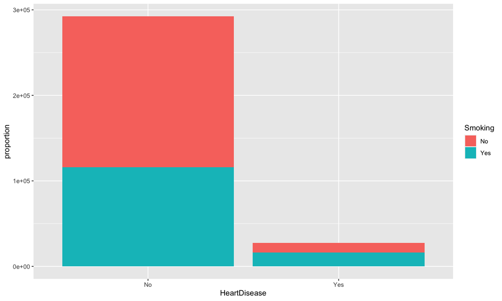

```r
ggplot(health_data, aes(x = HeartDisease, fill = Smoking)) +
geom_bar() +
xlab("HeartDisease") +
ylab("proportion")
```

### Exploratory visualization: stacked bar plot of proportion table

```r
tab = as.data.frame(propTable)
tab
```

A data.frame: 4 × 3

| HeartDisease <fct> | Smoking <fct> | Freq <dbl> |
| --- | --- | --- |
| No | No | 0.55 |
| Yes | No | 0.04 |
| No | Yes | 0.36 |
| Yes | Yes | 0.05 |

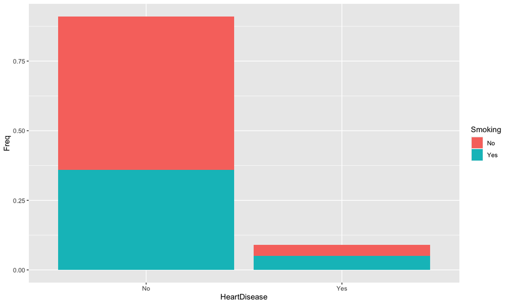

```r
ggplot(tab, aes(x = HeartDisease, y = Freq, fill = Smoking)) +
 geom_col()
```

**Test if there is any association between HeartDisease and Smoking.**

```
Null        H0: HeartDisease and Smoking are independent.
Alternative H1: HeartDisease and Smoking are dependent.
```

```r
#ConTable = table(HeartDisease = health_data$HeartDisease, Smoking = health_data$Smoking)
test = chisq.test(ConTable)
test
```

```
	Pearson's Chi-squared test with Yates' continuity correction

data:  ConTable
X-squared = 3713, df = 1, p-value < 2.2e-16
```

- Observation: $p-value < 2.2e-16$ which is much less than alpha of 0.05. Hence, we reject the null hypothesis
- Conclusion: HeartDisease and smooking are related.

**Expected Frequencies**

```r
test$expected
```

A matrix: 2 × 2 of type dbl

|  | No | Yes |
| --- | --- | --- |
| No | 171804.73 | 120617.27 |
| Yes | 16082.27 | 11290.73 |

**Observed Frequencies**

```r
test$observed
```

```
            Smoking
HeartDisease     No    Yes
         No  176551 115871
         Yes  11336  16037
```

```
                          Good Luck!
```